# HW3-exploration

Author

Stephen Carroll

Published

February 25, 2025

## Background questions

1. Which option do you plan to pursue? It’s okay if this has changed since HW #1.

**I will be completing an infographic to satisfy option 1.**

2. Restate your question(s). Has this changed at all since HW #1? If yes, how so?

**How will climate change impact viticulture in British Columbia?**

```
  - What is the trend of budbreak date in recent years?
  - What is the average budbreak date for different varieties?
  - What are the different varietals that are the most popular?
  - What varieties of wine grapes are more susceptible to temperature anomalies brought on by climate change? Are they the popular ones?
```

3. Explain which variables from your data set(s) you will use to answer your question(s), and how.

**The primary variable that will be highlighted in my visualization is the `doy`, indicating the average day of the year that budbreak is observed. Budbreak is the phenological phase where the vine exits dormancy, defined as the the stage when 50% of bud nodes show new, green growth, marking the start of vine growth and photosynthesis. This main variable will be examined in the context of other variables like `year`, `variety`, `event` and `varietal_revenue`.**

4. Find at least two data visualizations that you could (potentially) borrow / adapt pieces from. Link to them or download and embed them into your .qmd file, and explain which elements you might borrow (e.g. the graphic form, legend design, layout, etc.).

World Cup Heatmap

- I really enjoy how this heatmap from [Tanya Shapiro](https://tanyaviz.com/) conveys both categorical and temporal data, while using color and shape to highlight significant cells. I will try to make something similar showing variety instead of country, and highlighting vintages where the annual `revenue_pcnt` is high or changes wuth color.

Future Winegrape Phenology in the Okanagan Valley

Flowering GDD trends over time

- The chart on the second page of this document titles ‘Variations in GDD across varieties’ has a general layout that could be adapted to show the differing budbreak over time for different varieties. Theirs is a bit busy, and I would probably favor a more simple dot or lollipop plot instead.

Winegrape Phenology in the Okanagan Valley

- For a general overview of what my infographic layout could resemble, though this factsheet is heavier on the information and less so on the visual elements.

SAINT-ÉMILION • POMEROL and their satellite appellations

- General inspiration for wine-centric data viz layout and style.
5. Hand-draw your anticipated visualizations

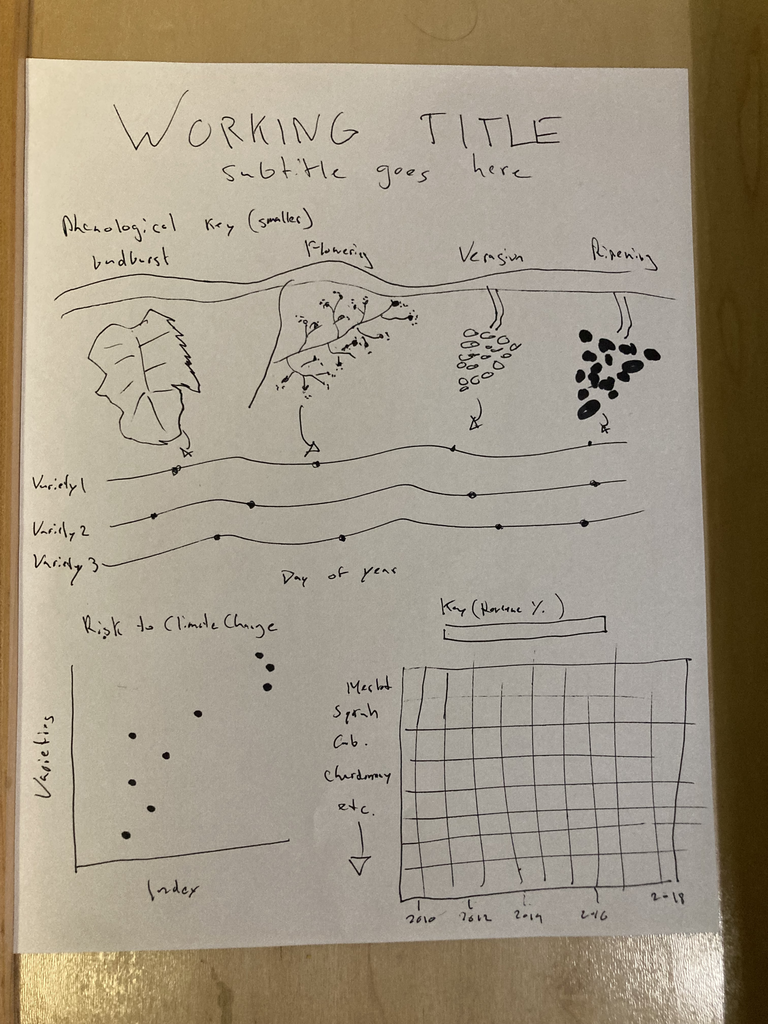

Sketch of infographic

6. Mock up all of your hand drawn visualizations using code. We understand that you will continue to iterate on these into HW #4 (particularly after receiving feedback), but by the end of HW #3, you should:

### See below

7. Answer the following questions:

[output not shown]

## Data Visualizations

### Packages

```r
library(tidyverse)
library(here)
library(ggplot2)
library(dplyr)
library(viridis)
library(showtext)
library(openxlsx)
```

### Data Load-In

```r
# Read in budburst data
budburst <- read_csv(here('data/data/budburst_est_2015.csv'))

# Read in vine cold-hardiness data
vines_cold <- read_csv(here('data/VineColdHardiness.csv'))

# Read in grape production data
# **Will change to revenue % for better representation of popularity**
ca_wine <- read.xlsx(here('data/california_without_raisin_and_table_grapes.xlsx'), sheet = "Area by V (ha)")

# Read in projected bb data
climate_future <- read_csv(here('data/ZDavis_data_4climatefuture.csv'),  show_col_types = FALSE)

# Read in projected bb data
phases <- read_csv(here('data/dat_4phases_noNA_2015.csv'), show_col_types = FALSE)

leafout <- read_csv(here('data/data/leafout_est_2015.csv'))
```

### Data cleaning

```r
# Clean production data
colnames(ca_wine) <- gsub("^area", "", colnames(ca_wine))

ca_wine_long <- ca_wine %>%
  pivot_longer(cols = -variety, names_to = "year", values_to = "area_ha") %>%
  mutate(year = as.integer(year)) %>%
  filter(!is.na(area_ha), year >= 2000) %>%
  mutate(area_rank = factor(dense_rank(desc(area_ha))))

#### Go back and use janitor and possibly combine different datasets into one main set
```

### Heatmap

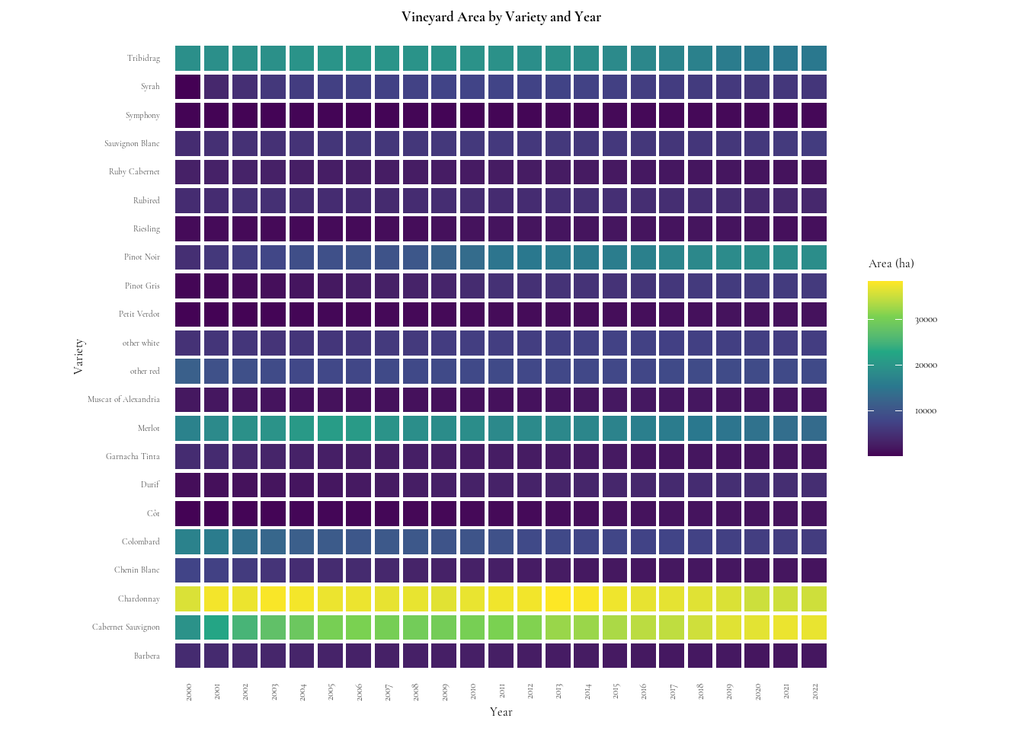

```r
# Set font
font_add_google(name = "Cormorant Garamond", family = "cormorant")
showtext_auto()

# Heatmap of variety popularity (vineyard area) by year
ggplot(ca_wine_long, aes(x = factor(year), y = variety, fill = area_ha)) +
  geom_tile(color = "white", width = 0.9, height = 0.9) +
  scale_fill_viridis_c(option = "viridis", name = "Area (ha)") +
  coord_equal() +
  labs(
    title = "Vineyard Area by Variety and Year",
    x = "Year",
    y = "Variety") +

  theme_minimal(base_size = 12,
                base_family = "cormorant") +
  theme(plot.title = element_text(face = "bold",
                                  size = 14,
                                  hjust = 0.5,
                                  margin = margin(b = 8)),
    axis.text.x = element_text(angle = 90, vjust = 0.5, hjust = 1),
    axis.text.y = element_text(size = 8),
    panel.grid = element_blank(),
    axis.ticks = element_blank())
```

### Phenological Events Plot

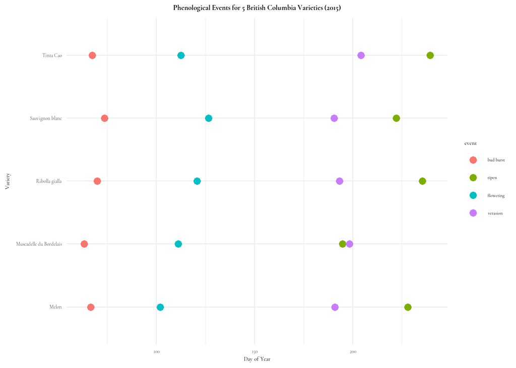

```r
# make a vector of 5 varieties
popular_varietals <- phases %>%
  distinct(variety) %>%
  slice_sample(n = 5) %>%
  pull(variety)

# Make a basic dot plot
ggplot(
  phases %>%
    filter(variety %in% popular_varietals),
  aes(x = variety, y = doy.2015, color = event)) +

  geom_point(size = 3) +
  scale_color_discrete(
    labels = c(bb = "bud burst",
               brix22 = "ripen",
               flo  = "flowering",
               ver = "verasion")) +
  labs(title = "Phenological Events for 5 British Columbia Varieties (2015)",
       x = "Variety",
       y = "Day of Year") +

  coord_flip() +

  theme_minimal(base_family = "cormorant") +

  theme(plot.title = element_text(face = "bold",
                                  size = 14,
                                  hjust = 0.5),
    axis.text.y = element_text(size = 10),
    axis.text.x = element_text(size = 10))
```

### Lethal Cold Temperature (LTE) Plot

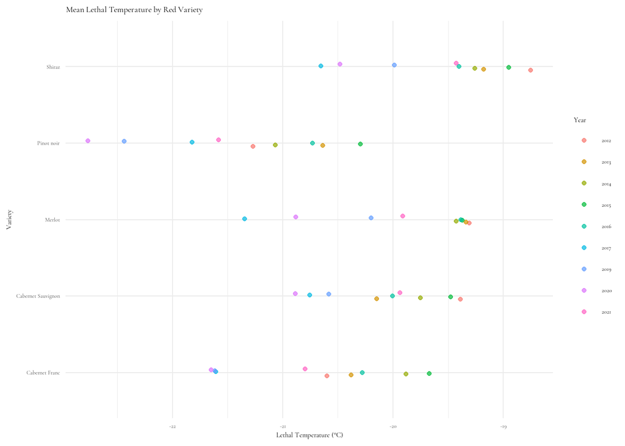

```r
# calculate the mean lte for each variety in each year
mean_lte_summary <- vines_cold %>%
  group_by(variety, year) %>%
  summarise(mean_lte = mean(lte, na.rm = TRUE), .groups = "drop")

top_reds <- c("Merlot", "Pinot noir", "Cabernet Sauvignon", "Cabernet Franc", "Shiraz")

top_whites <- c("Pinot gris", "Chardonnay", "Riesling", "Gewurztraminer", "Sauvignon blanc")

mean_lte_summary %>%
  filter(variety %in% top_reds) %>%
  mutate(year = factor(year)) %>%
  ggplot(aes(x = mean_lte, y = variety, color = year)) +
  geom_point(alpha = 0.7,
             position = position_dodge(width = 0.1),) +

  labs(title = "Mean Lethal Temperature by Red Variety",
       x = "Lethal Temperature (°C)",
       y = "Variety",
       color = "Year") +

  theme_minimal(base_family = "cormorant")
```

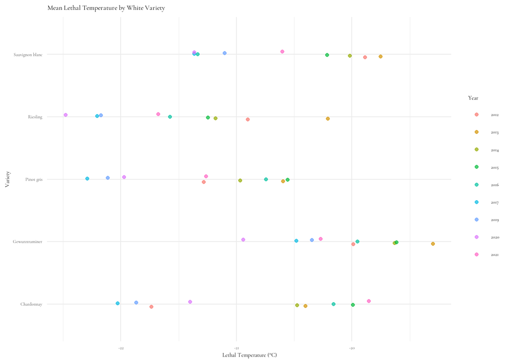

```r
mean_lte_summary %>%
  filter(variety %in% top_whites) %>%
  mutate(year = factor(year)) %>%
  ggplot(aes(x = mean_lte, y = variety, color = year)) +
  geom_point(alpha = 0.7,
             position = position_dodge(width = 0.1),) +
  labs(
    title = "Mean Lethal Temperature by White Variety",
    x = "Lethal Temperature (°C)",
    y = "Variety",
    color = "Year") +
  theme_minimal(base_family = "cormorant")
```